# Лабораторная работа 1

Простые модели компьютерной сети

Хассан Ф .А.

Российский университет дружбы народов, Москва, Россия

Объединённый институт ядерных исследований, Дубна, Россия

# Информация

## Докладчик

- Хассан Факи Абакар
- студент
- Российский университет дружбы народов
- 1032215869@pfur.ru
- https://fakhassan.github.io/ru/

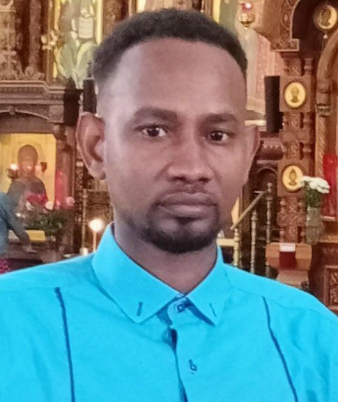

## Цели и задачи

Приобрести навыки моделирования сетей передачи данных с помощью средства имитационного моделирования NS-2, а также проанализировать полученные результаты моделирования.

## Материалы и методы

- Процессор `pandoc` для входного формата Markdown
- Результирующие форматы
  - `pdf`
  - `html`
- Автоматизация процесса создания: `Makefile`

# Создание презентации

## Процессор `pandoc`

- Pandoc: преобразователь текстовых файлов
- Сайт: https://pandoc.org/
- Репозиторий: https://github.com/jgm/pandoc

## Формат `pdf`

- Использование LaTeX
- Пакет для презентации: beamer
- Тема оформления: `metropolis`

## Код для формата `pdf`

```yaml
slide_level: 2
aspectratio: 169
section-titles: true
theme: metropolis
```

## Формат `html`

- Используется фреймворк [reveal.js](https://revealjs.com/)
- Используется [тема](https://revealjs.com/themes/) `beige`

## Код для формата `html`

- Тема задаётся в файле `Makefile`

```
REVEALJS_THEME = beige
```

# Результаты

## Получающиеся форматы

- Полученный `pdf`-файл можно демонстрировать в любой программе просмотра `pdf`
- Полученный `html`-файл содержит в себе все ресурсы: изображения, css, скрипты

# Элементы презентации

## Задание

1. Создать шаблон сценария для NS-2;
2. Выполнить простой пример описания топологии сети, состоящей из двух узлов и одного соединения;
3. Выполнить пример с усложнённой топологией сети;
4. Выполнить пример с кольцевой топологией сети;
5. Выполнить упражнение.

# Выполнение лабораторной работы

## Шаблон сценария для NS-2

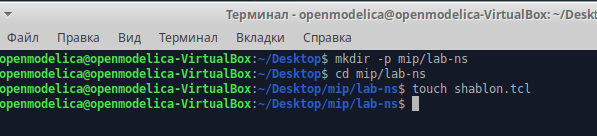

Создание директорий и файла

## Шаблон сценария для NS-2

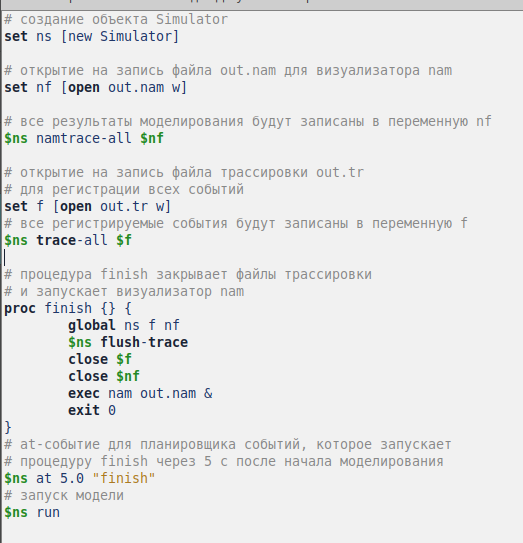

Редактирование файла shablon.tcl

## Шаблон сценария для NS-2

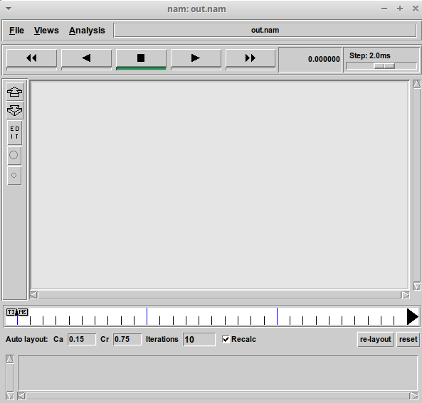

Запуск шаблона сценария для NS-2

## Простой пример описания топологии сети, состоящей из двух узлов и одного соединения

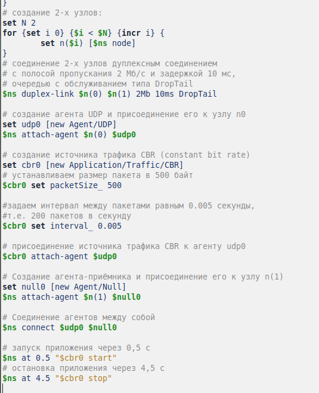

Пример описания топологии сети, состоящей из двух узлов и одного соединения

## Простой пример описания топологии сети, состоящей из двух узлов и одного соединения

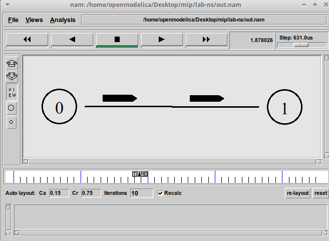

Визуализация простой модели сети с помощью nam

## Пример с усложнённой топологией сети

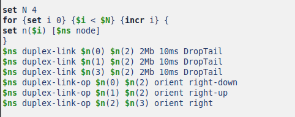

## Пример с усложнённой топологией сети

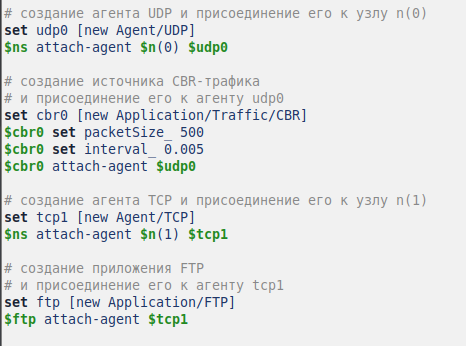

Описание усложненной топологии сети

## Пример с усложнённой топологией сети

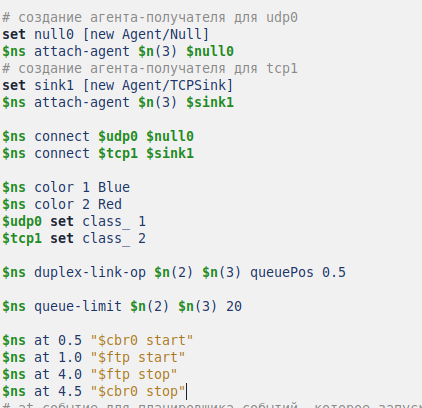

Описание усложненной топологии сети

## Пример с усложнённой топологией сети

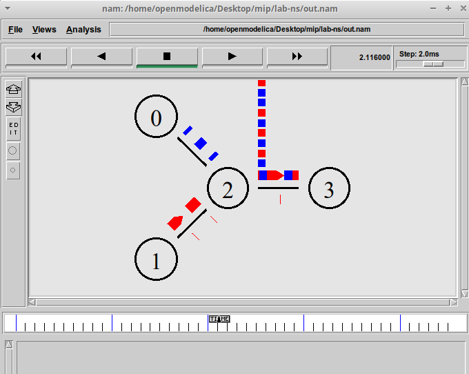

## Пример с кольцевой топологией сети

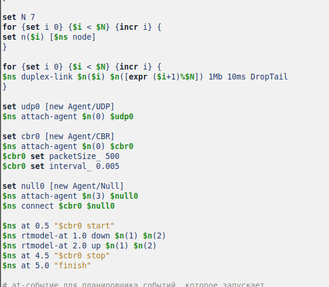

Описание кольцевой топологии сети и динамической маршрутизацией пакетов

## Пример с кольцевой топологией сети

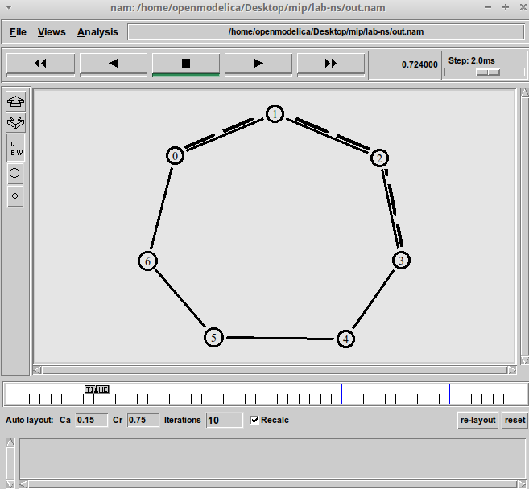

Передача данных по кратчайшему пути сети с кольцевой топологией

## Пример с кольцевой топологией сети

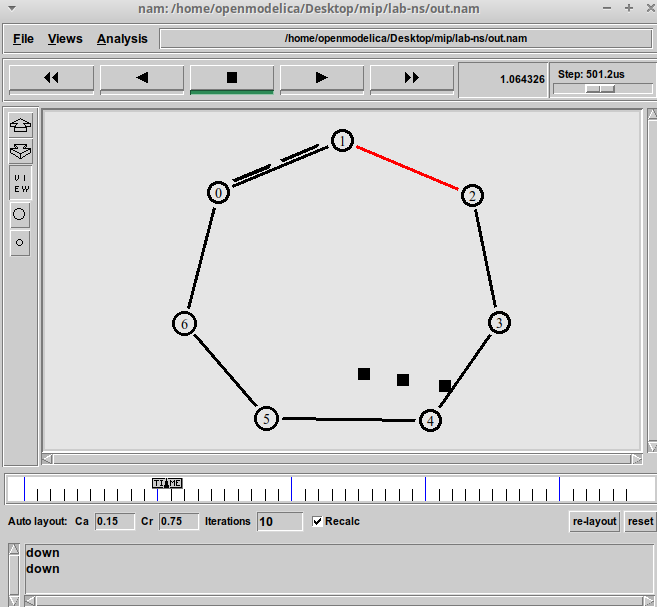

Передача данных по сети с кольцевой топологией в случае разрыва соединения

## Пример с кольцевой топологией сети

Добавив в начало скрипта после команды создания объекта Simulator:

`$ns rtproto DV`

увидим, что сразу после запуска в сети отправляется небольшое количество маленьких пакетов, используемых для обмена информацией, необходимой для маршрутизации между узлами.

## Пример с кольцевой топологией сети

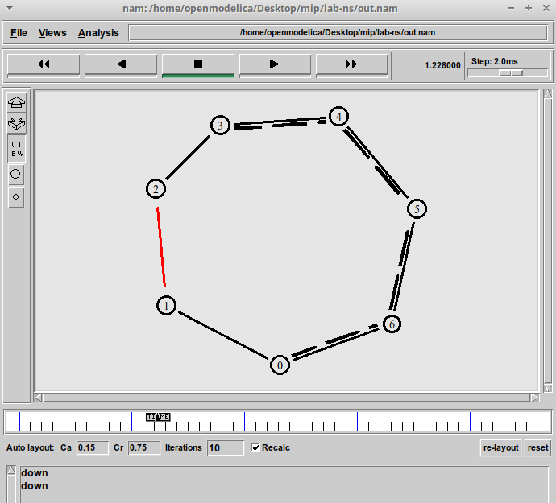

Маршрутизация данных по сети с кольцевой топологией в случае разрыва соединения

## Упражнение

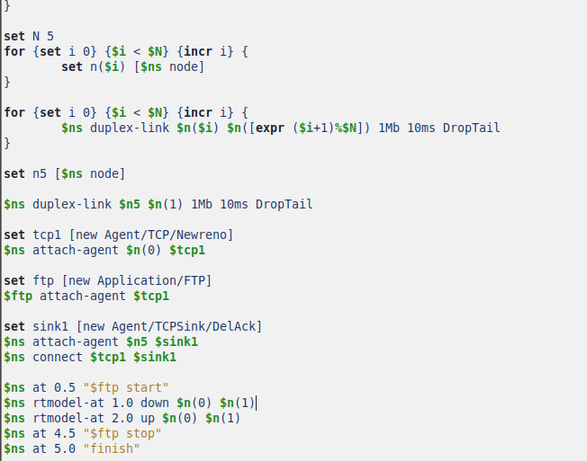

Программа для упражнения по построению топологии сети

## Упражнение

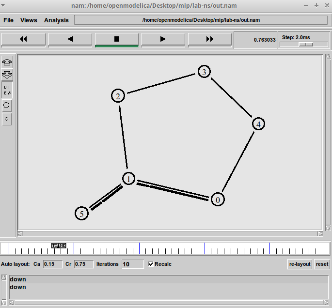

Передача данных по изменённой кольцевой топологии сети

## Упражнение

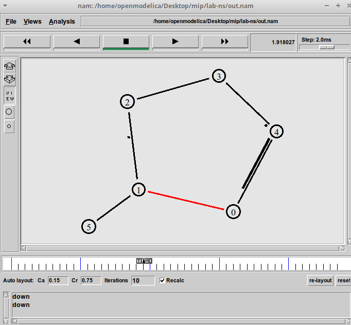

Передача данных по сети в случае разрыва соединения

## Упражнение

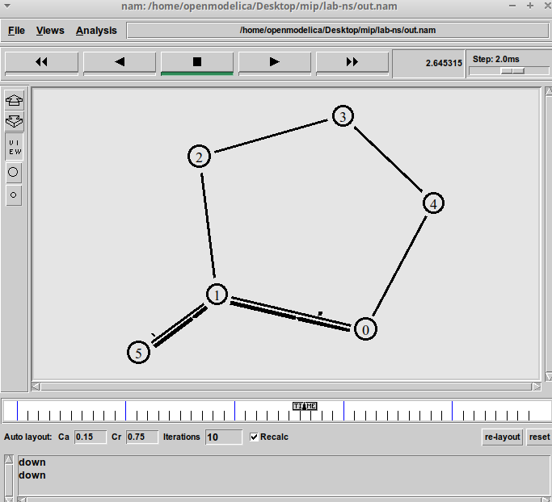

Передача данных после восстановления соединения

## Выводы

В процессе выполнения данной лабораторной работы я приобрела навыки моделирования сетей передачи данных с помощью средства имитационного моделирования NS-2, а также проанализировала полученные результаты моделирования.